# Báo Cáo Kiểm Tra Lần 2 - Khoa Học Dữ Liệu 1

Nguyễn Lan Anh

2026-06-04

## Bài tập Nhóm 1: Tiền xử lý dữ liệu và Khám phá phân phối

### 1. Khởi tạo và Làm sạch dữ liệu

Sinh mẫu ngẫu nhiên 5000 quan sát từ phân phối chuẩn N(60, 15^2) rồi chèn lỗi NA với số âm vào.

```r
set.seed(123)
t_raw <- rnorm(5000, mean = 60, sd = 15)

# Chen 150 vi tri NA
na_pos <- sample(1:5000, 150)
t_raw[na_pos] <- NA

# Chen 50 so am vao cac vi tri con lai
safe_pos <- which(!is.na(t_raw))
neg_pos <- sample(safe_pos, 50)
t_raw[neg_pos] <- runif(50, -15, -1)

# Loc bo NA va cac so am
t_clean <- t_raw[!is.na(t_raw) & t_raw >= 0]
df1 <- tibble(Time = t_clean)
df1
```

```
## # A tibble: 4,800 × 1
##     Time
##    <dbl>
##  1  51.6
##  2  56.5
##  3  83.4
##  4  61.1
##  5  61.9
##  6  85.7
##  7  66.9
##  8  41.0
##  9  49.7
## 10  53.3
## # ℹ 4,790 more rows
```

Số quan sát ban đầu là 5000. Sau khi lọc bỏ 150 NA và 50 số âm thì còn lại 4800 dòng.

### 2. Khám phá phân phối

Tính trung bình và độ lệch chuẩn của dữ liệu sạch:

```r
mean_t <- mean(df1$Time)
sd_t <- sd(df1$Time)
mean_t
```

```
## [1] 60.01987
```

```r
sd_t
```

```
## [1] 14.8881
```

Vẽ Histogram và chèn đường mật độ chuẩn N(mean_t, sd_t^2) lên:

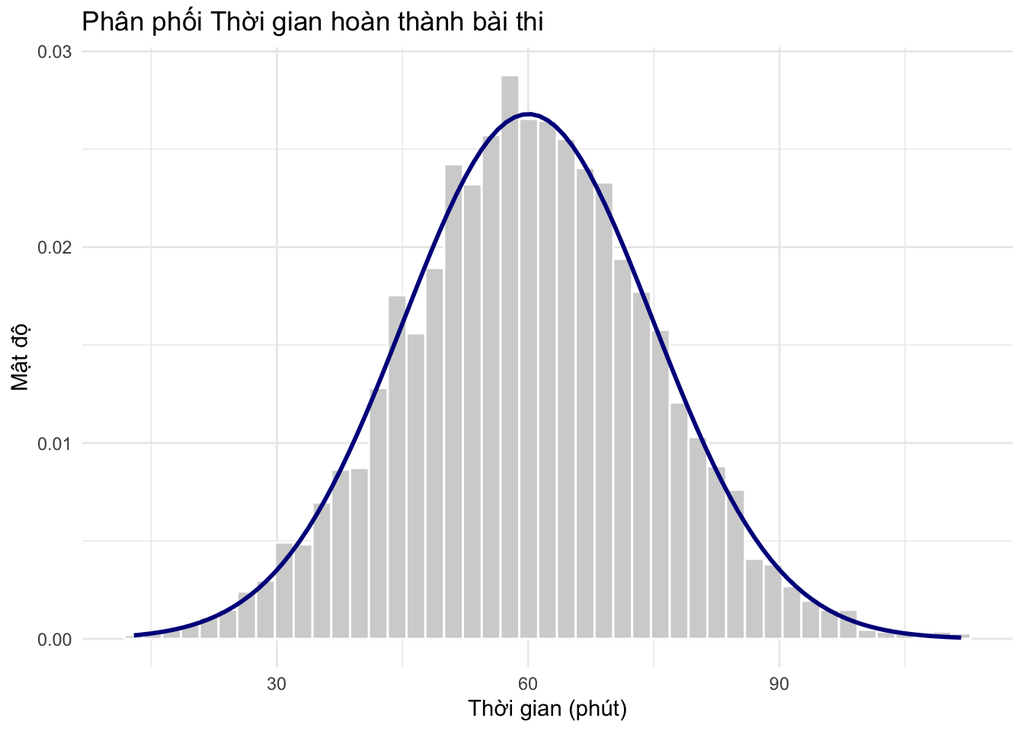

```r
ggplot(df1, aes(x = Time)) +
  geom_histogram(aes(y = after_stat(density)), fill = "lightgray", color = "white", bins = 45) +
  geom_function(fun = dnorm, args = list(mean = mean_t, sd = sd_t), color = "darkblue", linewidth = 1) +
  labs(title = "Phân phối Thời gian hoàn thành bài thi",
       x = "Thời gian (phút)",
       y = "Mật độ") +
  theme_minimal()
```

Đường mật độ chuẩn màu xanh khớp khá tốt với histogram.

### 3. Tính xác suất sinh viên hoàn thành dưới 45 phút

```r
prob <- pnorm(45, mean = mean_t, sd = sd_t)
prob
```

```
## [1] 0.156523
```

Xác suất sinh viên làm xong dưới 45 phút là tầm 15.65%.

### 4. Tìm mốc thời gian của top 5% nhanh nhất

Top 5% nhanh nhất ứng với phân vị 0.05 ở phía đuôi bên trái:

```r
cutoff <- qnorm(0.05, mean = mean_t, sd = sd_t)
cutoff
```

```
## [1] 35.53113
```

Mốc thời gian để được nhận thưởng là dưới 35.53 phút.

## Bài tập Nhóm 2: Lập trình Mô phỏng và Hệ quả CLT

### 1. Viết hàm mô phỏng

```r
clt <- function(n, lambda, R = 5000) {
  means_vector <- numeric(R)
  for (i in 1:R) {
    means_vector[i] <- mean(rexp(n, rate = lambda))
  }
  return(means_vector)
}
```

### 2. Kiểm chứng hội tụ

Mô phỏng trung bình mẫu của phân phối mũ với n = 40, lambda = 0.2. Kỳ vọng lý thuyết là 5, phương sai lý thuyết là 0.625 (độ lệch chuẩn là căn của 0.625).

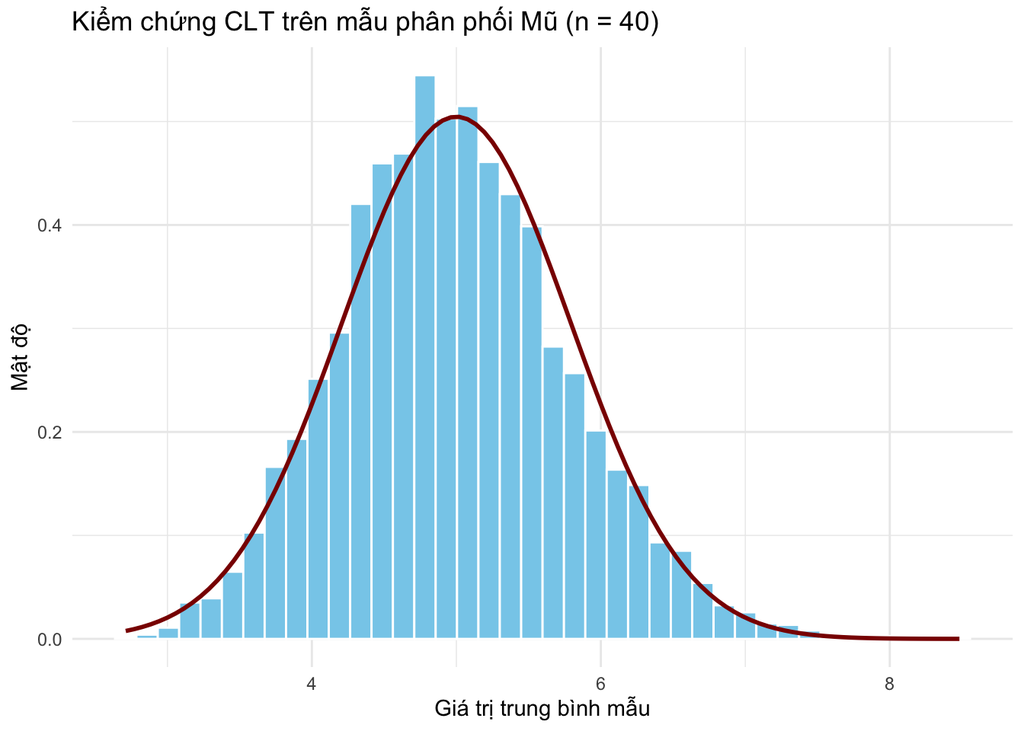

```r
means <- clt(n = 40, lambda = 0.2, R = 5000)
df_clt <- tibble(Mean_Values = means)

mu_lt <- 1 / 0.2
sd_lt <- sqrt(1 / (40 * 0.2^2))

ggplot(df_clt, aes(x = Mean_Values)) +
  geom_histogram(aes(y = after_stat(density)), fill = "skyblue", color = "white", bins = 40) +
  geom_function(fun = dnorm, args = list(mean = mu_lt, sd = sd_lt),
                color = "darkred", linewidth = 1) +
  labs(title = "Kiểm chứng CLT trên mẫu phân phối Mũ (n = 40)",
       x = "Giá trị trung bình mẫu",
       y = "Mật độ") +
  theme_minimal()
```

Histogram xấp xỉ rất tốt đường cong chuẩn lý thuyết.

### 3. Khoảng tin cậy mẫu cho Phương sai

Rút 1 mẫu ngẫu nhiên n = 30 từ phân phối mũ:

```r
set.seed(789)
mau_exp <- rexp(30, rate = 0.2)
n_s <- length(mau_exp)
s2 <- var(mau_exp)

# Tra gia tri toi han Chi-square
chi1 <- qchisq(0.975, df = n_s - 1)
chi2 <- qchisq(0.025, df = n_s - 1)

ci_low <- ((n_s - 1) * s2) / chi1
ci_up <- ((n_s - 1) * s2) / chi2

ktc_df <- tibble(Lower = ci_low, Upper = ci_up)
ktc_df
```

```
## # A tibble: 1 × 2
##   Lower Upper
##   <dbl> <dbl>
## 1  14.0  39.8
```

### 4. Vẽ đồ thị khoảng tin cậy

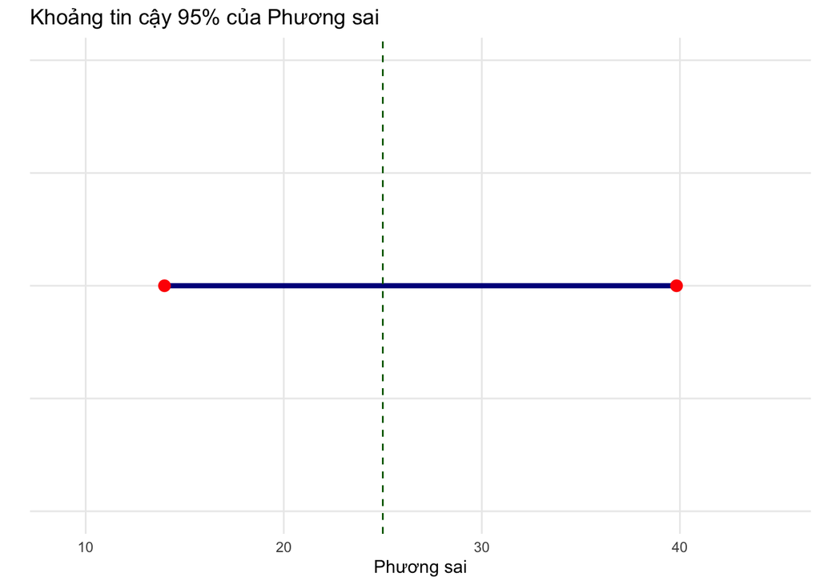

```r
ggplot() +
  geom_segment(aes(x = ci_low, y = 1, xend = ci_up, yend = 1), color = "darkblue", linewidth = 1.5) +
  geom_point(aes(x = c(ci_low, ci_up), y = c(1, 1)), color = "red", size = 3) +
  geom_vline(xintercept = 1 / (0.2^2), linetype = "dashed", color = "darkgreen") +
  xlim(ci_low - 5, ci_up + 5) +
  ylim(0, 2) +
  labs(title = "Khoảng tin cậy 95% của Phương sai",
       x = "Phương sai",
       y = "") +
  theme_minimal() +
  theme(axis.text.y = element_blank(),
        axis.ticks.y = element_blank(),
        panel.grid.minor = element_blank())
```

Phương sai thực tế (25) nằm gọn trong khoảng tin cậy ước lượng.

## Bài tập Nhóm 3 (Capstone Project): Ước lượng Điểm và Khoảng Toàn diện

### 1. Khởi tạo dữ liệu RAM

Tạo 3000 quan sát từ phân phối Beta(2, 5).

```r
set.seed(2026)
df3 <- tibble(ram = rbeta(3000, shape1 = 2, shape2 = 5))
df3
```

```
## # A tibble: 3,000 × 1
##       ram
##     <dbl>
##  1 0.403
##  2 0.115
##  3 0.315
##  4 0.269
##  5 0.169
##  6 0.0164
##  7 0.160
##  8 0.122
##  9 0.309
## 10 0.199
## # ℹ 2,990 more rows
```

### 2. Ước lượng Mô-men (MoM)

```r
mean_ram <- mean(df3$ram)
var_ram <- var(df3$ram)

k_mom <- (mean_ram * (1 - mean_ram) / var_ram) - 1
a_mom <- mean_ram * k_mom
b_mom <- (1 - mean_ram) * k_mom

a_mom
```

```
## [1] 1.999164
```

```r
b_mom
```

```
## [1] 5.033594
```

### 3. Ước lượng Hợp lý Cực đại (MLE)

Hàm trừ log-likelihood cho phân phối Beta:

```r
nll_func <- function(theta, data) {
  a <- theta[1]
  b <- theta[2]
  return(-sum(dbeta(data, shape1 = a, shape2 = b, log = TRUE)))
}

fit <- nlminb(start = c(a_mom, b_mom), objective = nll_func,
              data = df3$ram, lower = c(1e-5, 1e-5))

a_mle <- fit$par[1]
b_mle <- fit$par[2]

a_mle
```

```
## [1] 2.035029
```

```r
b_mle
```

```
## [1] 5.105974
```

### 4. So sánh kết quả ước lượng MoM và MLE

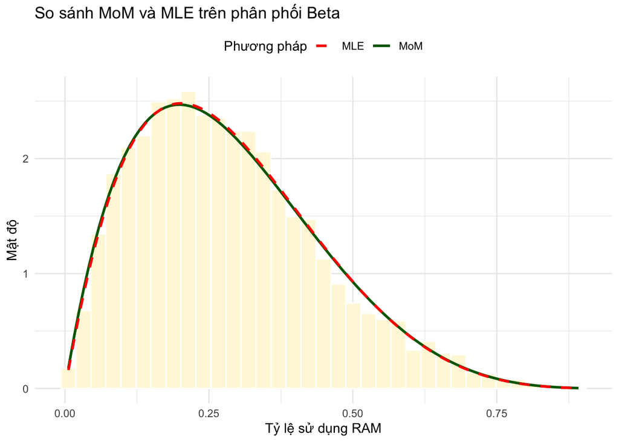

```r
ggplot(df3, aes(x = ram)) +
  geom_histogram(aes(y = after_stat(density)), fill = "cornsilk", color = "white", bins = 35) +
  geom_function(fun = dbeta, args = list(shape1 = a_mom, shape2 = b_mom),
                aes(color = "MoM"), linewidth = 1) +
  geom_function(fun = dbeta, args = list(shape1 = a_mle, shape2 = b_mle),
                aes(color = "MLE"), linetype = "dashed", linewidth = 1) +
  scale_color_manual(values = c("MoM" = "darkgreen", "MLE" = "red")) +
  labs(title = "So sánh MoM và MLE trên phân phối Beta",
       x = "Tỷ lệ sử dụng RAM",
       y = "Mật độ",
       color = "Phương pháp") +
  theme_minimal() +
  theme(legend.position = "top")
```

Hai đường mật độ của MoM và MLE gần như đè khít lên nhau.

### 5. Khoảng tin cậy phi tham số cho Trung vị

```r
n_r <- length(df3$ram)
alpha <- 0.01

idx1 <- qbinom(alpha / 2, size = n_r, prob = 0.5)
idx2 <- qbinom(1 - alpha / 2, size = n_r, prob = 0.5)

sorted_ram <- sort(df3$ram)
med_low <- sorted_ram[idx1]
med_up <- sorted_ram[idx2 + 1]

med_low
```

```
## [1] 0.2530067
```

```r
med_up
```

```
## [1] 0.2720197
```

```r
median(df3$ram)
```

```
## [1] 0.2628202
```

Trung vị mẫu rơi đúng vào khoảng tin cậy 99% tìm được.